# Example of using metR package

Data for this example are downloaded from site: http://www.neuroepigenomics.org/methylomedb/download.html We used 4 control samples: Control1 AC, Control2 AC, Control3 AC and Control4 AC and 4 disease samples: SCZ1 AC, SCZ2 AC, SCZ3 AC, SCZ4 AC. After downloading we summed all results on the same position and chromosome separately from control and disease samples.

In this file we created analysis of DMR in chromosome 1. The code about preprocessing files can be found in examples/prep.MethylomeDB.R in this repo. Result of this script are two data.frames: examples/control.Rds and examples/disease.Rds which are used in this document.

Let’s analyze!

Read our data:

```r
control <- readRDS('control.rds')
datatable(head(control))
```

|  | chr | poz | no | meth | unmeth | meth.rate |
| --- | --- | --- | --- | --- | --- | --- |
| 1 | chr1 | 73465 | 6 | 1 | 5 | 0.166666666666667 |
| 2 | chr1 | 73467 | 6 | 1 | 5 | 0.166666666666667 |
| 3 | chr1 | 74406 | 10 | 5 | 5 | 0.5 |
| 4 | chr1 | 74873 | 10 | 5 | 5 | 0.5 |
| 5 | chr1 | 75268 | 10 | 5 | 5 | 0.5 |
| 6 | chr1 | 75390 | 10 | 5 | 5 | 0.5 |

```r
disease <- readRDS('disease.rds')
datatable(head(disease))
```

|  | chr | poz | no | meth | unmeth | meth.rate |
| --- | --- | --- | --- | --- | --- | --- |
| 1 | chr1 | 4603 | 5 | 2 | 3 | 0.4 |
| 2 | chr1 | 4609 | 5 | 2 | 3 | 0.4 |
| 3 | chr1 | 4635 | 5 | 2 | 3 | 0.4 |
| 4 | chr1 | 4637 | 5 | 2 | 3 | 0.4 |
| 5 | chr1 | 4653 | 5 | 2 | 3 | 0.4 |
| 6 | chr1 | 4750 | 5 | 2 | 3 | 0.4 |

Preprocess data:

```r
data <- preprocessing(control, disease)
```

Now we have one data.frame with all necessary values binding on chromosome and position:

```r
datatable(head(data))
```

|  | chr | poz | prob | no | meth | unmeth | meth.rate |
| --- | --- | --- | --- | --- | --- | --- | --- |
| 1 | chr1 | 81412 | x | 35 | 29 | 6 | 0.828571428571429 |
| 2 | chr1 | 81412 | y | 76 | 66 | 10 | 0.868421052631579 |
| 3 | chr1 | 81442 | x | 35 | 29 | 6 | 0.828571428571429 |
| 4 | chr1 | 81442 | y | 76 | 66 | 10 | 0.868421052631579 |
| 5 | chr1 | 81546 | x | 35 | 29 | 6 | 0.828571428571429 |
| 6 | chr1 | 81546 | y | 76 | 66 | 10 | 0.868421052631579 |

So we can create region. After creation they will be tested if there is significant difference between two probes in methylation rate.

One way is to use create.tiles.fixed.length function, See ?create.tiles.fixed.length if you want some details.

```r
data.tiles.1 <- create.tiles.fixed.length(data, tiles.length = 1000, common = F)
datatable(head(data.tiles.1))
```

|  | chr | poz | prob | no | meth | unmeth | meth.rate | tiles |
| --- | --- | --- | --- | --- | --- | --- | --- | --- |
| 1 | chr1 | 81412 | x | 35 | 29 | 6 | 0.828571428571429 | 81 |
| 2 | chr1 | 81412 | y | 76 | 66 | 10 | 0.868421052631579 | 81 |
| 3 | chr1 | 81442 | x | 35 | 29 | 6 | 0.828571428571429 | 81 |
| 4 | chr1 | 81442 | y | 76 | 66 | 10 | 0.868421052631579 | 81 |
| 5 | chr1 | 81546 | x | 35 | 29 | 6 | 0.828571428571429 | 81 |
| 6 | chr1 | 81546 | y | 76 | 66 | 10 | 0.868421052631579 | 81 |

```r
data.tiles.2 <- create.tiles.fixed.length(data, tiles.length = 1000, common = T)
datatable(head(data.tiles.2))
```

|  | chr | poz | prob | no | meth | unmeth | meth.rate | tiles | tiles.common |
| --- | --- | --- | --- | --- | --- | --- | --- | --- | --- |
| 1 | chr1 | 81412 | x | 35 | 29 | 6 | 0.828571428571429 | 81 | 81 |
| 2 | chr1 | 81412 | y | 76 | 66 | 10 | 0.868421052631579 | 81 | 81 |
| 3 | chr1 | 81442 | x | 35 | 29 | 6 | 0.828571428571429 | 81 | 81 |
| 4 | chr1 | 81442 | y | 76 | 66 | 10 | 0.868421052631579 | 81 | 81 |
| 5 | chr1 | 81546 | x | 35 | 29 | 6 | 0.828571428571429 | 81 | 82 |
| 6 | chr1 | 81546 | y | 76 | 66 | 10 | 0.868421052631579 | 81 | 82 |

We can can also use create.tiles.max.gap. See ?create.tiles.max.gap if you want some details.

```r
data.tiles.3 <- create.tiles.max.gap(data, gaps.length = 100)
datatable(head(data.tiles.3))
```

|  | chr | poz | prob | no | meth | unmeth | meth.rate | tiles |
| --- | --- | --- | --- | --- | --- | --- | --- | --- |
| chr1.1 | chr1 | 81412 | x | 35 | 29 | 6 | 0.828571428571429 | 1 |
| chr1.2 | chr1 | 81412 | y | 76 | 66 | 10 | 0.868421052631579 | 1 |
| chr1.3 | chr1 | 81442 | x | 35 | 29 | 6 | 0.828571428571429 | 1 |
| chr1.4 | chr1 | 81442 | y | 76 | 66 | 10 | 0.868421052631579 | 1 |
| chr1.5 | chr1 | 81546 | x | 35 | 29 | 6 | 0.828571428571429 | 2 |
| chr1.6 | chr1 | 81546 | y | 76 | 66 | 10 | 0.868421052631579 | 2 |

Now we can compare how perform our functions.

```r
stats.1 <- get.stats(data.tiles.1)
stats.2 <- get.stats(data.tiles.2)
stats.3 <- get.stats(data.tiles.3)
datatable(head(stats.3))
```

|  | chr | start | end | meth.cov | meth.max_x | meth.max_y | meth.mean_x | meth.mean_y | meth.min_x | meth.min_y | meth.sd_x | meth.sd_y | meth.diff | quantile |
| --- | --- | --- | --- | --- | --- | --- | --- | --- | --- | --- | --- | --- | --- | --- |
| 1 | chr1 | 81412 | 81442 | 2 | 0.828571428571429 | 0.868421052631579 | 0.828571428571429 | 0.868421052631579 | 0.828571428571429 | 0.868421052631579 | 0 | 0 | 0.0398496240601504 | 0.467264890222206 |
| 2 | chr1 | 81546 | 81546 | 1 | 0.828571428571429 | 0.868421052631579 | 0.828571428571429 | 0.868421052631579 | 0.828571428571429 | 0.868421052631579 |  |  | 0.0398496240601504 | 0.40515964448383 |
| 3 | chr1 | 81698 | 81863 | 4 | 0.828571428571429 | 0.868421052631579 | 0.828571428571429 | 0.868421052631579 | 0.828571428571429 | 0.868421052631579 | 0 | 0 | 0.0398496240601504 | 0.533362910723889 |
| 4 | chr1 | 81984 | 82025 | 3 | 0.828571428571429 | 0.868421052631579 | 0.825210084033613 | 0.867251461988304 | 0.823529411764706 | 0.866666666666667 | 0.00291100976062002 | 0.00101289520910461 | 0.0420413779546908 | 0.523590313926598 |
| 5 | chr1 | 82254 | 82254 | 1 | 0.823529411764706 | 0.855263157894737 | 0.823529411764706 | 0.855263157894737 | 0.823529411764706 | 0.855263157894737 |  |  | 0.031733746130031 | 0.340059709139977 |
| 6 | chr1 | 82603 | 82625 | 2 | 0.727272727272727 | 0.884615384615385 | 0.727272727272727 | 0.884615384615385 | 0.727272727272727 | 0.884615384615385 | 0 | 0 | 0.157342657342657 | 0.879514242343834 |

We got basic statistics about two probes. This is helpful if we want check coverage of created regions or methylation difference.

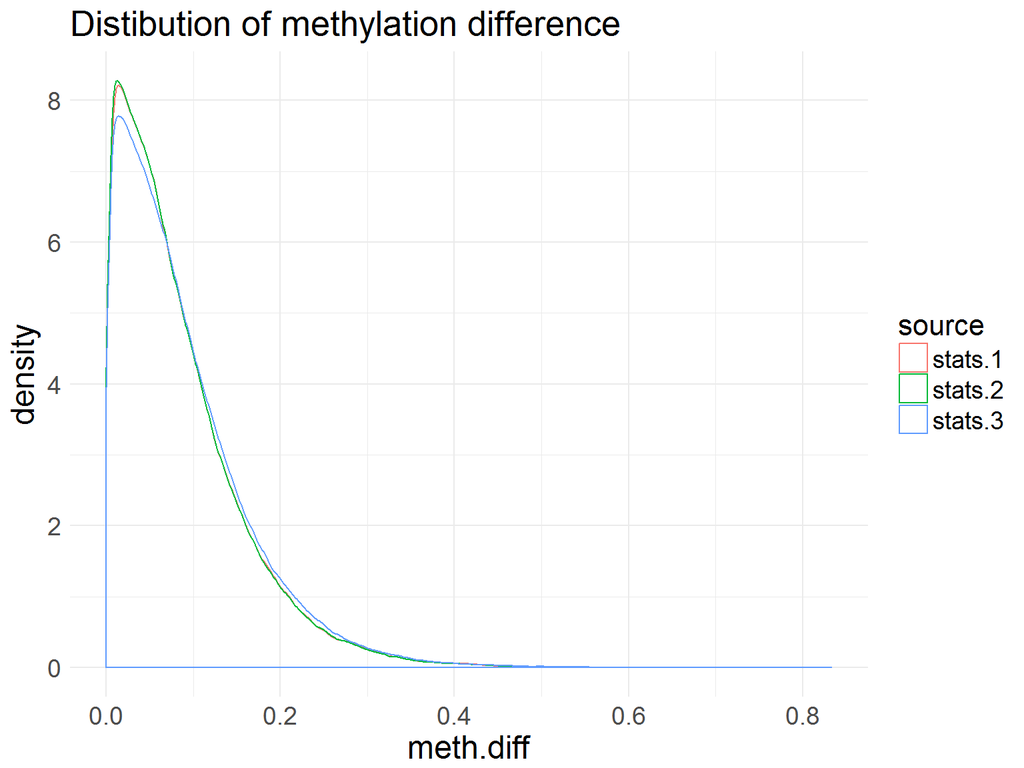

```r
stats.all <- gdata::combine(stats.1, stats.2, stats.3)

ggplot(stats.all, aes(x = meth.diff, group = source, col = source)) + geom_density() + theme_minimal() +
  ggtitle('Distibution of methylation difference') +
  theme(
      plot.title = element_text(size=20),
      axis.title.x = element_text(size=18),
      axis.title.y = element_text(size=18),
      axis.text.x = element_text(size=14),
      axis.text.y = element_text(size=14),
      legend.text = element_text(size = 14),
      legend.title = element_text(size = 16))
```

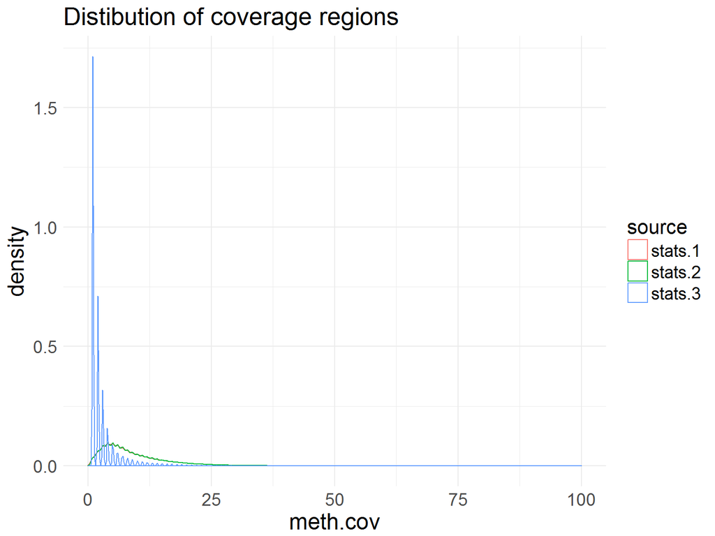

```r
ggplot(stats.all, aes(x = meth.cov, group = source, col = source)) + geom_density() + theme_minimal() + xlim(0,100) +
  ggtitle('Distibution of coverage regions') +
    theme(
      plot.title = element_text(size=20),
      axis.title.x = element_text(size=18),
      axis.title.y = element_text(size=18),
      axis.text.x = element_text(size=14),
      axis.text.y = element_text(size=14),
      legend.text = element_text(size = 14),
      legend.title = element_text(size = 16))
```

We also can join e.g stats.3 and data.tiles.3 on chromosome, start and end column and analyzing regions only if they coverage is greater than some specyfic values or other condition.

Get DMR basen on creation regions by create.tiles.max.gap function. See ?find.DMR if you want some details.

```r
result <- find.DMR(data.tiles.3, methods = c('Wilcoxon', 'Ttest', 'KS', 'Reg.Log', 'Reg.Mixed', 'Reg.Corr.Mixed'))
```

[output not shown]

Based on draw.methylation function we plotted ten best result from find.DMR.

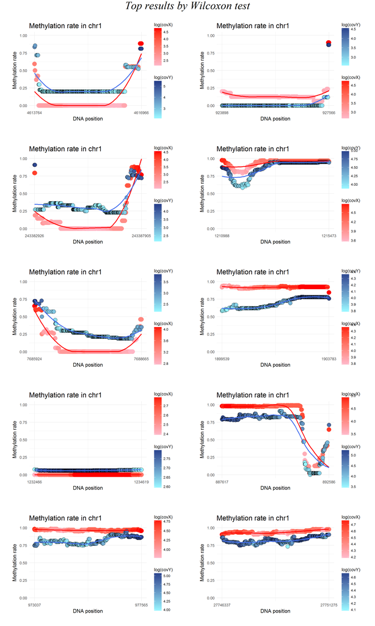

```r
top.n <- function(result, data, title){
  p <- list()
  for (i in 1:10){
  p[[i]] <- draw.methylation(data, chromosom = 'chr1', start = pull(result[i, 'start']), end = pull(result[i, 'end']), bind.probes = F,
        size.x.dot = 7, size.y.dot = 4, plot.title = 16, axis.title.x = 12, axis.title.y = 12, legend.title = 10, legend.text = 8,
        axis.text.x = 9, axis.text.y = 9)
  }

  grid.arrange(arrangeGrob(p[[1]], p[[2]], ncol = 2),
  arrangeGrob(p[[3]], p[[4]], ncol = 2),
  arrangeGrob(p[[5]], p[[6]], ncol = 2),
  arrangeGrob(p[[7]], p[[8]], ncol = 2),
  arrangeGrob(p[[9]], p[[10]], ncol = 2),
             nrow = 5, top=textGrob(title, gp=gpar(fontsize=25,font=8)))
}

top.n(result$Wilcoxon, data, 'Top results by Wilcoxon test')
```

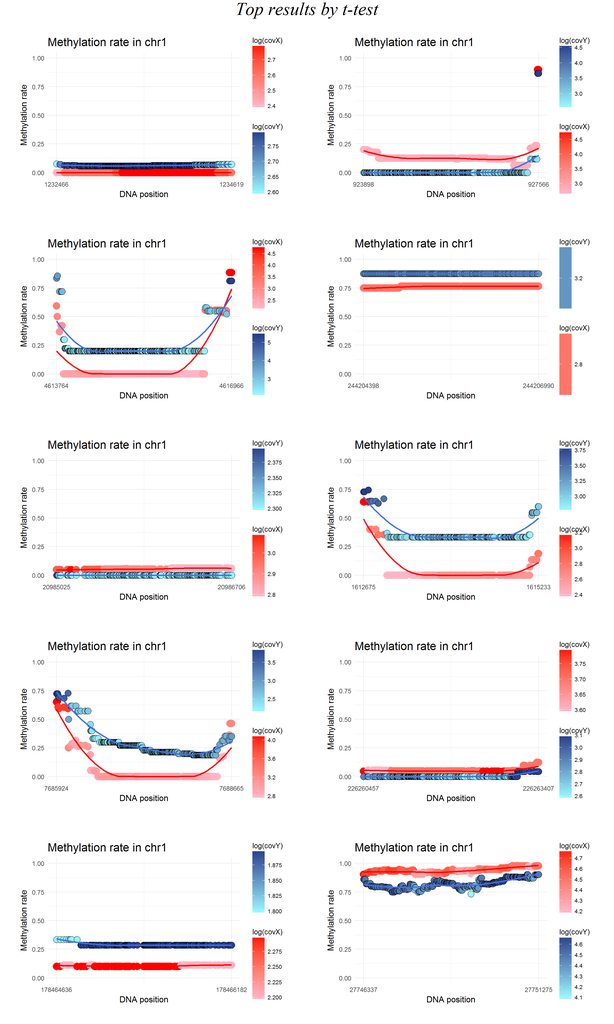

```r
top.n(result$Ttest, data, 'Top results by t-test')
```

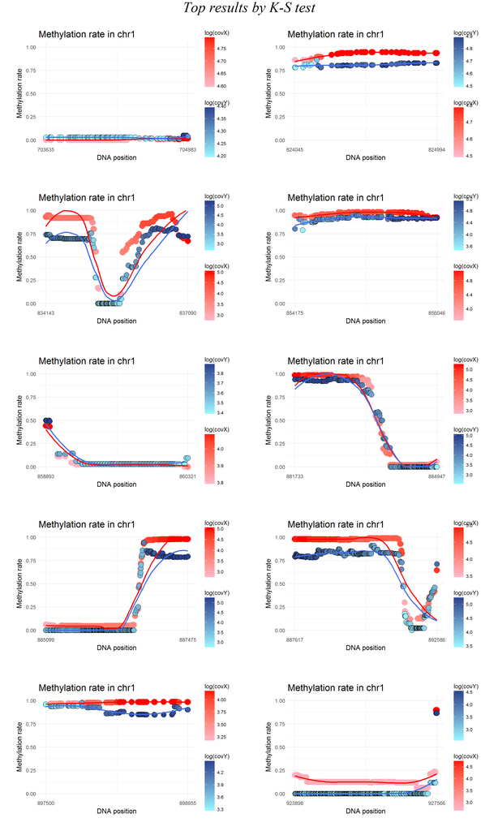

```r
top.n(result$KS, data, 'Top results by K-S test')
```

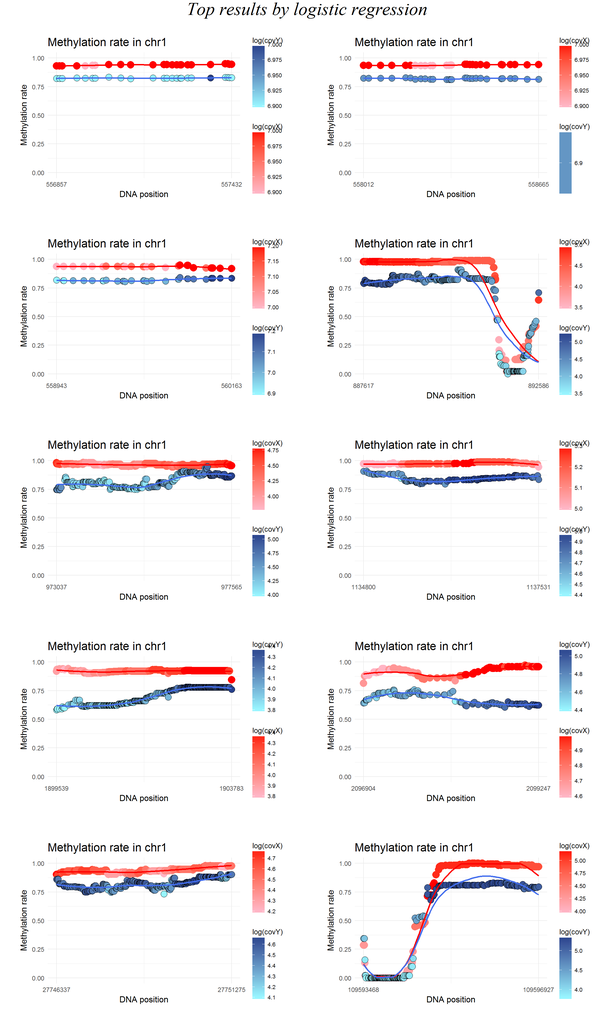

```r
top.n(result$Reg.Log, data, 'Top results by logistic regression')
```

We can also sorting regions from logistic regression by effect.size:

```r
result$Reg.Log.Beta <- result$Reg.Log %>% filter(p.value < 0.001) %>% arrange(-abs(beta.coef))
```

The outcome above is equivalent if we run:

```r
result <- find.DMR(data.tiles.3, methods = c('Reg.Log'), p.value.log.reg = 0.001)
```

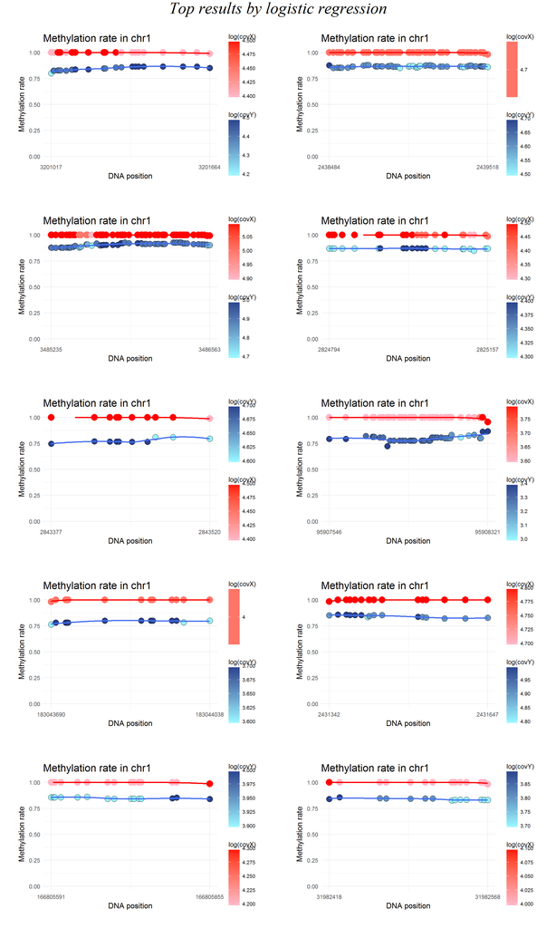

```r
top.n(result$Reg.Log.Beta, data, 'Top results by logistic regression')
```

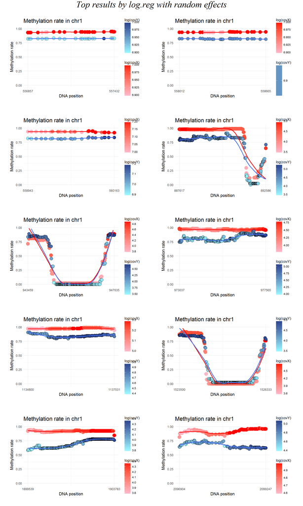

```r
top.n(result$Reg.Mixed, data, 'Top results by log.reg with random effects')
```